# Hemagglutinin HA1 Chain

Fold-switch pair **3ztjE_5hmgA** — **3ztjE** vs **5hmgA**

Influenza A virus (A/Aichi/2/1968(H3N2))

## Figure 1: Phylogenetic tree with per-cluster fold-preference heatmap.

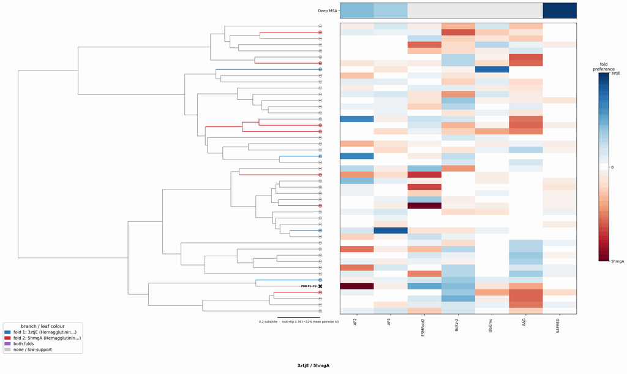

## Figure 2: Aligned overlay (both folds superposed)

The single fold-switching chain of each fold superposed by TM-align; waters hidden, any ligand shown as green sticks. Grey = structurally conserved core, colour = divergent (fold-switching) region.

3ztjE (Hemagglutinin HA1 Chain) · tetramer5hmgA (Hemagglutinin HA1 Chain) · dimerLigand BMA|NAG (bound to 3ztjE), Ligand MAN|NAG|SIA (bound to 5hmgA)

TM-score: 0.994 · Trigger class: ligand

Aligned overlay

## Figure 3: The two folds, side by side

Each fold is coloured by per-residue Cα deviation between the two superposed structures: grey ≈ conserved core, full colour = structurally divergent (fold-switching) region.

3ztjE (Hemagglutinin HA1 Chain)

5hmgA (Hemagglutinin HA1 Chain)

0 Å5≥10 Å

3ztjE (Hemagglutinin HA1 Chain)

5hmgA (Hemagglutinin HA1 Chain)

## Figure 4: Best-cluster predicted contact maps over the two true folds.

Predicted contact maps (MSA-Transformer) for the clusters best matching each fold, over the true contacts of fold 1 (upper triangle) and fold 2 (lower). Divergent contacts between clusters are the contact-level signature of fold-switching.

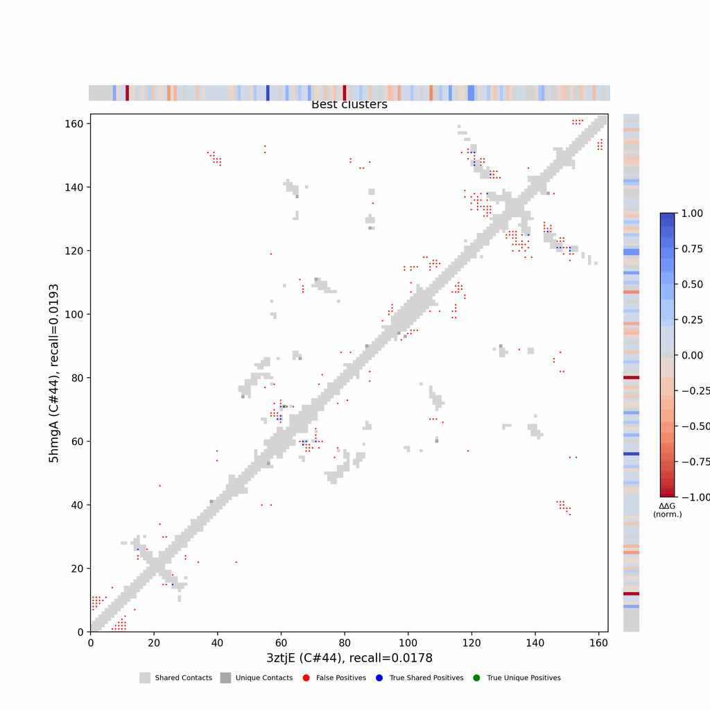

## Figure 5: Per-residue ΔΔG fold-preference contribution

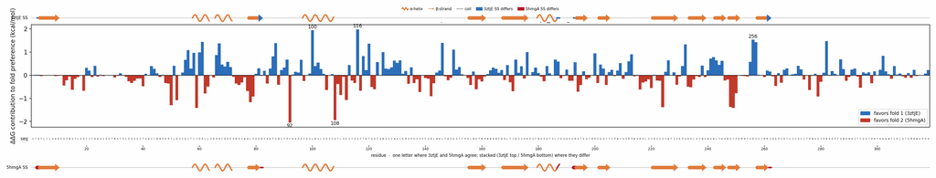

**More figures**

## Figure 6: Deep-MSA contact map panel / Best clusters contact map panel

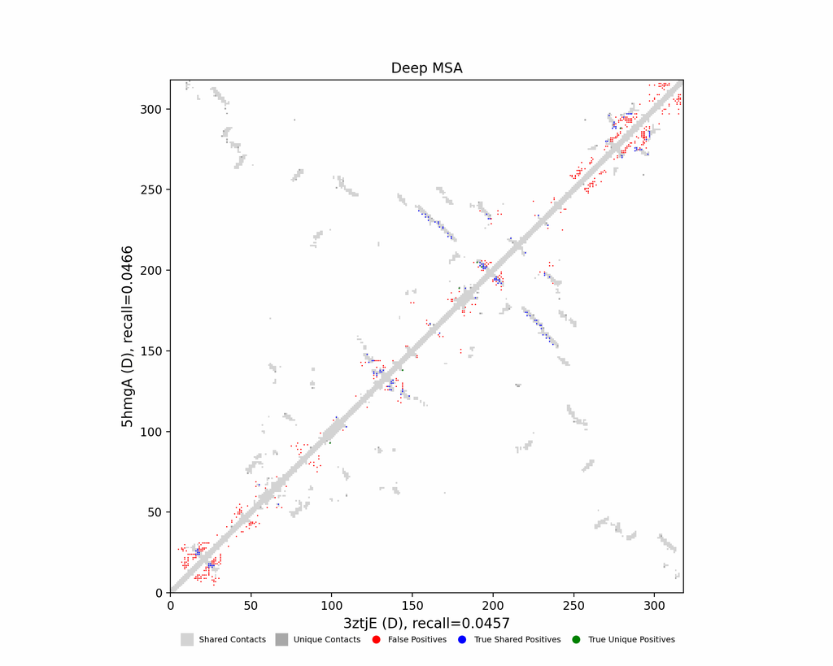

Deep-MSA contact map panel

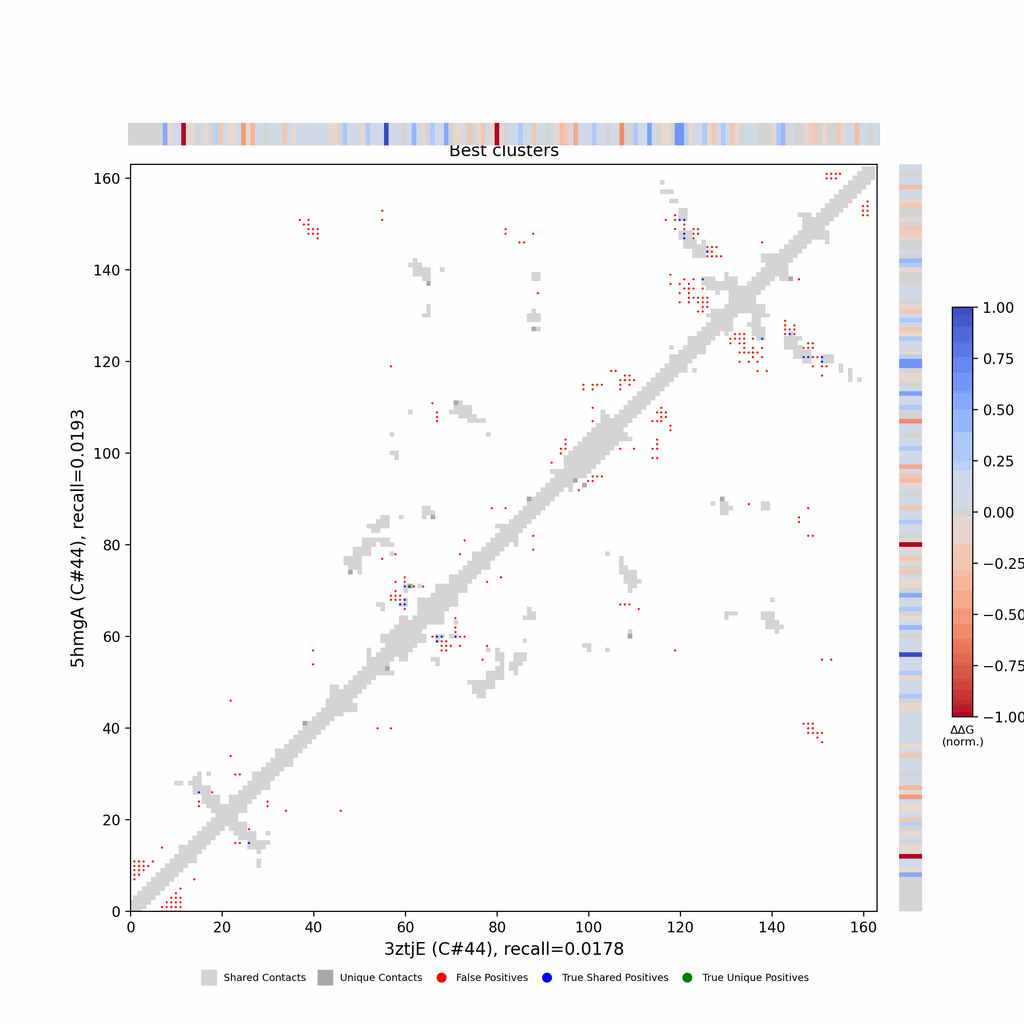

Best clusters contact map panel

## Figure 7: All clusters contact-map mosaic (small multiples).

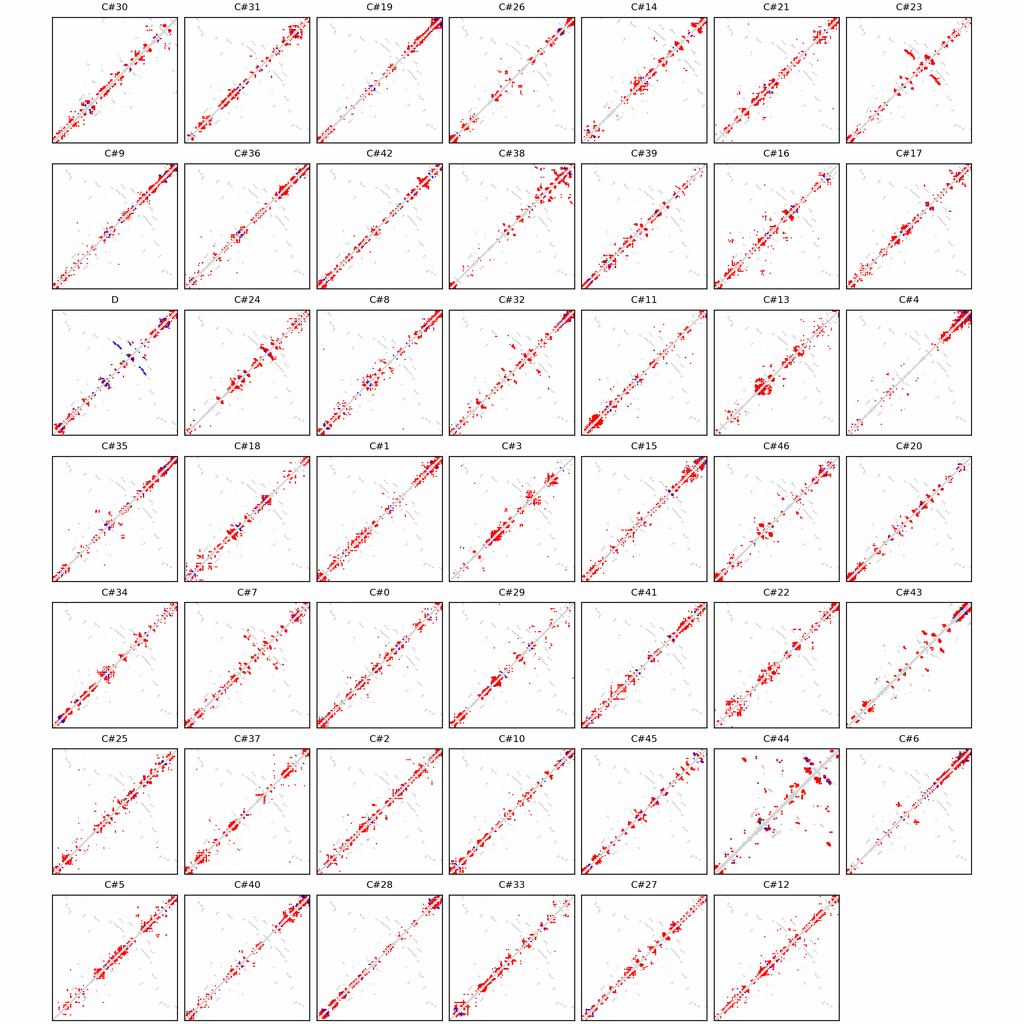

## Figure 8: Phylo null: tree with shuffled cluster fold labels.

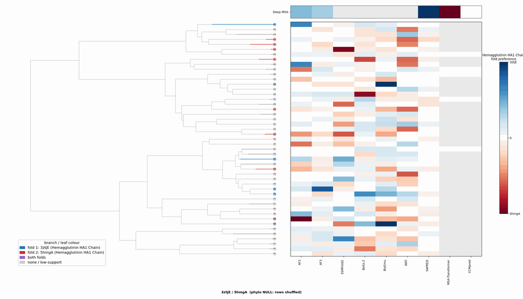

## Cluster metrics table

Per-cluster metrics underlying the figures above.

| cluster | n | neff | AF2_TM1 | AF2_TM2 | AF3_TM1 | AF3_TM2 | RE-MSAT-COM | RE-MSAT1 | RE-MSAT2 | ESM_SEQIDS | ESM_TM1 | ESM_TM2 | ΔΔG_Bias | ΔΔG_Bias_std | ΔΔG_frac_F1 | Boltz2_pref | S4PRED_pref | CCMpred_pref | BioEmu_pref |
| --- | --- | --- | --- | --- | --- | --- | --- | --- | --- | --- | --- | --- | --- | --- | --- | --- | --- | --- | --- |
| Deep | - | - | 0.93 | 0.9 | 0.95 | 0.94 | 0.05 | 0.05 | 0.05 | - | - | - | - | - | - | - | 0.03 | 0.0 | - |
| 000 | 86.0 | 3.0 | 0.32 | 0.32 | 0.37 | 0.36 | 0.0 | 0.0 | 0.0 | 006; 006; 001; 001; 007; 007; 009; 009; 002; 002 | 0.49 ± 0.04 | 0.48 ± 0.04 | 18.38 | 6.16 | 1.0 | 0.02 | 0.03 | 0.0 | 0.01 |
| 001 | 71.0 | 3.0 | 0.31 | 0.3 | 0.33 | 0.32 | 0.0 | 0.0 | 0.0 | 003; 003; 001; 001; 009; 008; 009; 002; 004; 008 | 0.49 ± 0.03 | 0.47 ± 0.03 | 16.0 | 5.42 | 1.0 | 0.02 | 0.03 | 0.0 | 0.01 |
| 002 | 66.0 | 1.0 | 0.22 | 0.22 | 0.36 | 0.35 | 0.0 | 0.0 | 0.0 | 001; 001; 006; 006; 007; 009; 007; 009; 008; 008 | 0.53 ± 0.03 | 0.52 ± 0.03 | 14.66 | 5.94 | 1.0 | 0.03 | 0.02 | 0.0 | 0.0 |
| 003 | 58.0 | 2.0 | 0.17 | 0.2 | 0.24 | 0.22 | 0.0 | 0.0 | 0.0 | 005; 001; 002; 006; 002; 001; 005; 006; 008; 008 | 0.51 ± 0.02 | 0.50 ± 0.02 | 20.03 | 1.65 | 1.0 | 0.02 | 0.03 | 0.0 | 0.0 |
| 004 | 55.0 | 2.0 | 0.2 | 0.2 | 0.37 | 0.36 | 0.01 | 0.01 | 0.01 | 005; 001; 002; 006; 002; 001; 005; 006; 008; 008 | 0.51 ± 0.02 | 0.50 ± 0.02 | 15.77 | 1.34 | 1.0 | 0.02 | 0.03 | 0.0 | 0.01 |
| 005 | 50.0 | 1.0 | 0.2 | 0.2 | 0.28 | 0.28 | 0.0 | 0.0 | 0.0 | 004; 005; 010; 001; 002; 006; 008; 007; 003; 009 | 0.42 ± 0.11 | 0.41 ± 0.11 | 1.36 | 2.22 | 0.6 | 0.02 | 0.03 | - | 0.0 |
| 006 | 48.0 | 3.0 | 0.22 | 0.21 | 0.27 | 0.26 | 0.0 | 0.0 | 0.0 | - | - | - | 16.31 | 2.6 | 1.0 | 0.02 | 0.03 | - | 0.01 |
| 007 | 46.0 | 8.0 | 0.25 | 0.21 | 0.22 | 0.21 | 0.0 | 0.0 | 0.0 | - | - | - | 16.84 | 4.72 | 1.0 | 0.02 | 0.03 | - | 0.01 |
| 008 | 41.0 | 4.0 | 0.24 | 0.29 | 0.28 | 0.27 | 0.01 | 0.01 | 0.01 | - | - | - | 6.37 | 6.94 | 0.8 | 0.03 | 0.03 | - | 0.0 |
| 009 | 40.0 | 1.0 | 0.24 | 0.23 | 0.25 | 0.24 | 0.0 | 0.0 | 0.0 | - | - | - | 16.75 | 1.09 | 1.0 | 0.02 | 0.02 | - | 0.0 |
| 010 | 36.0 | 4.0 | 0.18 | 0.19 | 0.2 | 0.19 | 0.0 | 0.0 | 0.0 | - | - | - | 17.49 | 4.65 | 1.0 | 0.02 | 0.02 | - | 0.0 |
| 011 | 36.0 | 1.0 | 0.2 | 0.19 | 0.2 | 0.2 | 0.0 | 0.0 | 0.0 | - | - | - | 23.9 | 0.73 | 1.0 | 0.02 | 0.03 | - | 0.0 |
| 012 | 36.0 | 1.0 | 0.26 | 0.25 | 0.31 | 0.3 | 0.0 | 0.0 | 0.0 | - | - | - | 25.21 | 0.85 | 1.0 | 0.02 | 0.03 | - | 0.0 |
| 013 | 35.0 | 2.0 | 0.3 | 0.3 | 0.34 | 0.33 | 0.0 | 0.0 | 0.0 | - | - | - | 22.83 | 0.91 | 1.0 | 0.01 | 0.03 | - | 0.01 |
| 014 | 34.0 | 4.0 | 0.25 | 0.25 | 0.4 | 0.39 | 0.0 | 0.0 | 0.0 | - | - | - | 12.45 | 5.64 | 1.0 | 0.01 | 0.03 | - | 0.01 |
| 015 | 32.0 | 1.0 | 0.18 | 0.17 | 0.21 | 0.21 | 0.0 | 0.0 | 0.0 | - | - | - | 15.86 | 1.32 | 1.0 | 0.02 | 0.03 | - | 0.0 |
| 016 | 32.0 | 1.0 | 0.18 | 0.18 | 0.25 | 0.25 | 0.0 | 0.0 | 0.0 | - | - | - | 2.73 | 0.77 | 1.0 | 0.02 | 0.03 | - | 0.01 |
| 017 | 31.0 | 3.0 | 0.18 | 0.18 | 0.36 | 0.35 | 0.0 | 0.0 | 0.0 | - | - | - | 12.1 | 6.28 | 1.0 | 0.02 | 0.03 | - | 0.0 |
| 018 | 30.0 | 2.0 | 0.23 | 0.22 | 0.24 | 0.23 | 0.0 | 0.0 | 0.0 | - | - | - | 0.55 | 1.99 | 0.6 | 0.02 | 0.03 | - | 0.0 |
| 019 | 28.0 | 1.0 | 0.25 | 0.24 | 0.27 | 0.27 | 0.0 | 0.0 | 0.0 | - | - | - | 15.68 | 0.96 | 1.0 | 0.02 | 0.03 | - | 0.0 |
| 020 | 26.0 | 7.0 | 0.19 | 0.19 | 0.21 | 0.2 | 0.0 | 0.0 | 0.0 | - | - | - | 17.62 | 2.81 | 1.0 | 0.01 | 0.03 | - | 0.01 |
| 021 | 26.0 | 1.0 | 0.34 | 0.33 | 0.35 | 0.34 | 0.0 | 0.0 | 0.0 | - | - | - | 24.74 | 1.94 | 1.0 | 0.02 | 0.03 | - | 0.01 |
| 022 | 26.0 | 2.0 | 0.28 | 0.28 | 0.28 | 0.27 | 0.0 | 0.0 | 0.0 | - | - | - | 1.76 | 1.95 | 0.7 | 0.03 | 0.02 | - | -0.0 |
| 023 | 25.0 | 9.0 | 0.5 | 0.48 | 0.53 | 0.52 | 0.0 | 0.0 | 0.0 | - | - | - | 11.18 | 5.13 | 1.0 | 0.01 | 0.03 | - | 0.01 |
| 024 | 24.0 | 3.0 | 0.21 | 0.22 | 0.22 | 0.22 | 0.0 | 0.0 | 0.0 | - | - | - | 16.56 | 4.88 | 1.0 | 0.01 | 0.03 | - | 0.0 |
| 025 | 24.0 | 1.0 | 0.24 | 0.23 | 0.3 | 0.29 | 0.0 | 0.0 | 0.0 | - | - | - | 1.95 | 1.24 | 1.0 | 0.03 | 0.03 | - | 0.0 |
| 026 | 24.0 | 1.0 | 0.2 | 0.16 | 0.23 | 0.23 | 0.01 | 0.01 | 0.01 | - | - | - | 2.24 | 0.91 | 1.0 | 0.02 | 0.03 | - | 0.01 |
| 027 | 23.0 | 3.0 | 0.24 | 0.24 | 0.18 | 0.18 | 0.0 | 0.0 | 0.0 | - | - | - | 16.57 | 5.37 | 1.0 | 0.02 | 0.03 | - | 0.02 |
| 028 | 23.0 | 2.0 | 0.17 | 0.18 | 0.22 | 0.22 | 0.0 | 0.0 | 0.0 | - | - | - | 16.91 | 1.94 | 1.0 | 0.02 | 0.03 | - | 0.0 |
| 029 | 23.0 | 1.0 | 0.21 | 0.21 | 0.27 | 0.26 | 0.0 | 0.0 | 0.0 | - | - | - | 20.86 | 4.17 | 1.0 | 0.02 | 0.03 | - | 0.01 |
| 030 | 22.0 | 1.0 | 0.23 | 0.23 | 0.28 | 0.27 | 0.0 | 0.0 | 0.0 | - | - | - | 9.79 | 4.7 | 1.0 | 0.01 | 0.03 | - | 0.0 |
| 031 | 22.0 | 3.0 | 0.18 | 0.17 | 0.16 | 0.16 | 0.0 | 0.0 | 0.0 | - | - | - | 3.52 | 3.23 | 1.0 | 0.01 | 0.03 | - | -0.0 |
| 032 | - | - | 0.18 | 0.21 | 0.26 | 0.25 | 0.0 | 0.0 | 0.0 | - | - | - | 23.42 | 3.93 | 1.0 | 0.02 | 0.03 | - | 0.0 |
| 033 | - | - | 0.21 | 0.21 | 0.24 | 0.23 | 0.0 | 0.0 | 0.0 | - | - | - | 1.3 | 0.81 | 0.9 | 0.0 | 0.03 | - | 0.0 |
| 034 | 22.0 | 6.0 | 0.19 | 0.19 | 0.26 | 0.26 | 0.01 | 0.01 | 0.01 | - | - | - | 22.68 | 6.02 | 1.0 | 0.01 | 0.03 | - | 0.01 |
| 035 | - | - | 0.24 | 0.23 | 0.24 | 0.24 | 0.01 | 0.01 | 0.01 | - | - | - | 15.31 | 1.2 | 1.0 | 0.01 | 0.03 | - | 0.0 |
| 036 | 21.0 | 1.0 | 0.23 | 0.2 | 0.31 | 0.3 | 0.0 | 0.0 | 0.0 | - | - | - | 15.65 | 1.88 | 1.0 | 0.02 | 0.02 | - | 0.0 |
| 037 | 21.0 | 3.0 | 0.28 | 0.28 | 0.37 | 0.36 | 0.0 | 0.0 | 0.0 | - | - | - | 19.06 | 1.71 | 1.0 | 0.03 | 0.03 | - | 0.01 |
| 038 | 21.0 | 1.0 | 0.46 | 0.45 | 0.55 | 0.54 | 0.0 | 0.0 | 0.0 | - | - | - | 14.03 | 9.87 | 1.0 | 0.0 | 0.03 | - | 0.01 |
| 039 | 21.0 | 1.0 | 0.17 | 0.16 | 0.21 | 0.2 | 0.0 | 0.0 | 0.0 | - | - | - | 19.83 | 5.63 | 1.0 | 0.01 | 0.03 | - | 0.0 |
| 040 | 21.0 | 1.0 | 0.19 | 0.2 | 0.27 | 0.27 | 0.01 | 0.01 | 0.01 | - | - | - | 16.38 | 0.96 | 1.0 | 0.02 | 0.03 | - | 0.0 |
| 041 | - | - | 0.2 | 0.18 | 0.24 | 0.19 | 0.0 | 0.0 | 0.0 | - | - | - | 15.97 | 1.13 | 1.0 | 0.01 | 0.03 | - | 0.01 |
| 042 | - | - | 0.19 | 0.18 | 0.24 | 0.23 | 0.01 | 0.01 | 0.0 | - | - | - | 16.6 | 0.99 | 1.0 | 0.01 | 0.03 | - | 0.0 |
| 043 | - | - | 0.22 | 0.2 | 0.4 | 0.39 | 0.0 | 0.01 | 0.0 | - | - | - | 13.15 | 4.96 | 1.0 | -0.0 | 0.03 | - | -0.0 |
| 044 | 20.0 | 4.0 | 0.26 | 0.25 | 0.57 | 0.55 | 0.0 | 0.0 | 0.0 | - | - | - | 8.99 | 2.22 | 1.0 | 0.01 | 0.03 | - | 0.01 |
| 045 | 20.0 | 3.0 | 0.21 | 0.19 | 0.21 | 0.21 | 0.0 | 0.0 | 0.0 | - | - | - | 16.98 | 2.17 | 1.0 | 0.0 | 0.03 | - | 0.0 |
| 046 | - | - | 0.37 | 0.36 | 0.5 | 0.49 | 0.0 | 0.0 | 0.0 | - | - | - | 9.96 | 2.41 | 1.0 | 0.02 | 0.03 | - | 0.0 |